# CoxPH

Author

Calvin Belton & James Walters

# 1 Setting up

```r
library(flexsurv)
library(ggplot2)
library(tidyverse)
library(ggfortify)# for `autoplot` with survfit
library(survminer)
library(kableExtra)
library(patchwork)
library(splines)
library(muhaz)
library(reporter)
library(gtsummary)
library(stringr)
```

## 1.1 Load previously ‘cleaned’ dataset

```r
load(file = "../Input_Data/monsurv.Rdata")
```

## 1.2 Function for saving files

```r
save_file <- function(test_obj, label, file){

  cat(
    "\n-----------------------------------\n",
    label,
    "\n-----------------------------------\n",
    file = file,
    append = TRUE
  )

  capture.output(
    test_obj,
    file = file,
    append = TRUE
  )
}
```

```r
survival_stats <- "../Results/Survival_CoxPH/Statistics/survival_stats.txt"

cat(
  "Monarch Manuscript Survival Results\n",
  "=================================\n\n",
  file = survival_stats
)
```

```r
mortality_stats <- "../Results/Survival_CoxPH/Statistics/mortality_statistics.txt"

cat(
  "Monarch Manuscript Mortality Results\n",
  "=================================\n\n",
  file = mortality_stats
)
```

```r
coxph_stats <- "../Results/Survival_CoxPH/Statistics/coxph_statistics.txt"

cat(
  "Monarch Manuscript Cox Proportional Hazards Results\n",
  "=================================\n\n",
  file = coxph_stats
)
```

```r
anova_stats <- "../Results/Survival_CoxPH/Statistics/ANOVA_statistics.txt"

cat(
  "Monarch Manuscript Cox Proportional Hazards ANOVA Results\n",
  "=================================\n\n",
  file = anova_stats
)
```

```r
diagnostics_stats <- "../Results/Survival_CoxPH/Statistics/diagnostics_statistics.txt"

cat(
  "Monarch Manuscript Diagnostics of Cox Proportional Hazards Models\n",
  "=================================\n\n",
  file = diagnostics_stats
)
```

## 1.3 Graphics

Before I start creating plots, I set up the custom theme and custom color palette that is continuous in my plots of monarch.

## 1.4 Custom theme

```r
theme_monarch <- theme_bw(base_size = 12) +
  theme(
    plot.title = element_text(face = "bold", hjust = 0.5, size = 14),
    axis.title = element_text(face = "bold", size = 13),
    axis.text = element_text(face = "bold", size = 11),
    strip.text = element_text(face = "bold")
  )
```

## 1.5 Graph systematics

```r
sex_colors <- c("Male" = "dodgerblue","Female" = "firebrick2")
```

# 2 Sex Comparison of Survival

## 2.1 Create Survival Object

```r
survMon <- Surv(time = monsurv$Age, event = monsurv$event)
```

## 2.2 Survdiff created: Kaplan-Mier statistics

```r
survMon.diff <- survdiff(survMon ~ Sex, data = monsurv)
print(survMon.diff)
```

```
Call:
survdiff(formula = survMon ~ Sex, data = monsurv)

             N Observed Expected (O-E)^2/E (O-E)^2/V
Sex=Male   424      424      483      7.13        18
Sex=Female 452      452      393      8.74        18

 Chisq= 18  on 1 degrees of freedom, p= 2e-05
```

```r
save_file(survMon.diff,"Kaplan-Mier statistics", survival_stats)
```

### 2.2.1 Find the p-value

```r
p <- survMon.diff$pvalue
save_file(p,"Kaplan-Mier p-value", survival_stats)
```

### 2.2.2 Analyze with survfit

```r
monsurv.fit <- survfit(Surv(Age) ~ Sex, data = monsurv)
print(monsurv.fit)
```

```
Call: survfit(formula = Surv(Age) ~ Sex, data = monsurv)

             n events median 0.95LCL 0.95UCL
Sex=Male   424    424     27      26      28
Sex=Female 452    452     25      25      26
```

```r
save_file(monsurv.fit,"Kaplan-Mier survfit survival estimation", survival_stats)
```

## 2.3 Kaplan-Meier Plot

```r
survivorship_plot <- ggsurvplot(
  monsurv.fit,
  conf.int = FALSE,
  palette = sex_colors,
  xlab = "Days Since Eclosion",
  ylab = "Survival Probability",
  legend.title = "Sex",
  legend.labs = c("Male", "Female"),
  legend = "right",
  size = 1,
  ggtheme = theme_monarch
)
```

### 2.3.1 Save Kaplan-Meier Plot

```r
ggsave(
  filename = "../Results/Survival_CoxPH/Figures/Figure_01_survivorship_plot.pdf",
  plot = survivorship_plot$plot,
  width = 180,
  height = 120,
  units = "mm",
  dpi = 300
)
```

# 3 Mortality rate visualization

## 3.1 Calculate qx ()

### 3.1.1 Summarize previously created survfit

```r
mon_sum <- summary(monsurv.fit)
str(mon_sum)
```

```
List of 20
 $ n            : int [1:2] 424 452
 $ time         : num [1:96] 2 4 6 8 9 10 11 12 13 14 ...
 $ n.risk       : num [1:96] 424 421 418 417 414 411 407 400 394 386 ...
 $ n.event      : num [1:96] 3 3 1 3 3 4 7 6 8 6 ...
 $ n.censor     : num [1:96] 0 0 0 0 0 0 0 0 0 0 ...
 $ surv         : num [1:96] 0.993 0.986 0.983 0.976 0.969 ...
 $ std.err      : num [1:96] 0.00407 0.00574 0.00619 0.00737 0.00837 ...
 $ cumhaz       : num [1:96] 0.00708 0.0142 0.01659 0.02379 0.03103 ...
 $ std.chaz     : num [1:96] 0.00409 0.0058 0.00627 0.00752 0.00861 ...
 $ strata       : Factor w/ 2 levels "Sex=Male","Sex=Female": 1 1 1 1 1 1 1 1 1 1 ...
 $ type         : chr "right"
 $ logse        : logi TRUE
 $ conf.int     : num 0.95
 $ conf.type    : chr "log"
 $ lower        : num [1:96] 0.985 0.975 0.971 0.962 0.953 ...
 $ upper        : num [1:96] 1 0.997 0.996 0.991 0.986 ...
 $ t0           : num 0
 $ call         : language survfit(formula = Surv(Age) ~ Sex, data = monsurv)
 $ table        : num [1:2, 1:9] 424 452 424 452 424 ...
  ..- attr(*, "dimnames")=List of 2
  .. ..$ : chr [1:2] "Sex=Male" "Sex=Female"
  .. ..$ : chr [1:9] "records" "n.max" "n.start" "events" ...
 $ rmean.endtime: num [1:2] 73 73
 - attr(*, "class")= chr "summary.survfit"
```

### 3.1.2 Generate life table, including generating qx

```r
mon_sum_DF <- data.frame(
  x   = mon_sum$time,
  nx = mon_sum$n.risk,
  lx   = mon_sum$surv,
  dx = mon_sum$n.event,
  lower  = mon_sum$lower,
  upper  = mon_sum$upper,
  strata = sub(x = mon_sum$strata, pattern = "Sex=", replacement = "")
)
mon_sum_DF$qx <- mon_sum_DF$dx/mon_sum_DF$nx
save_file(mon_sum_DF,"Life-table data", mortality_stats)
```

### 3.1.3 Visualize qx and log(qx) by sex

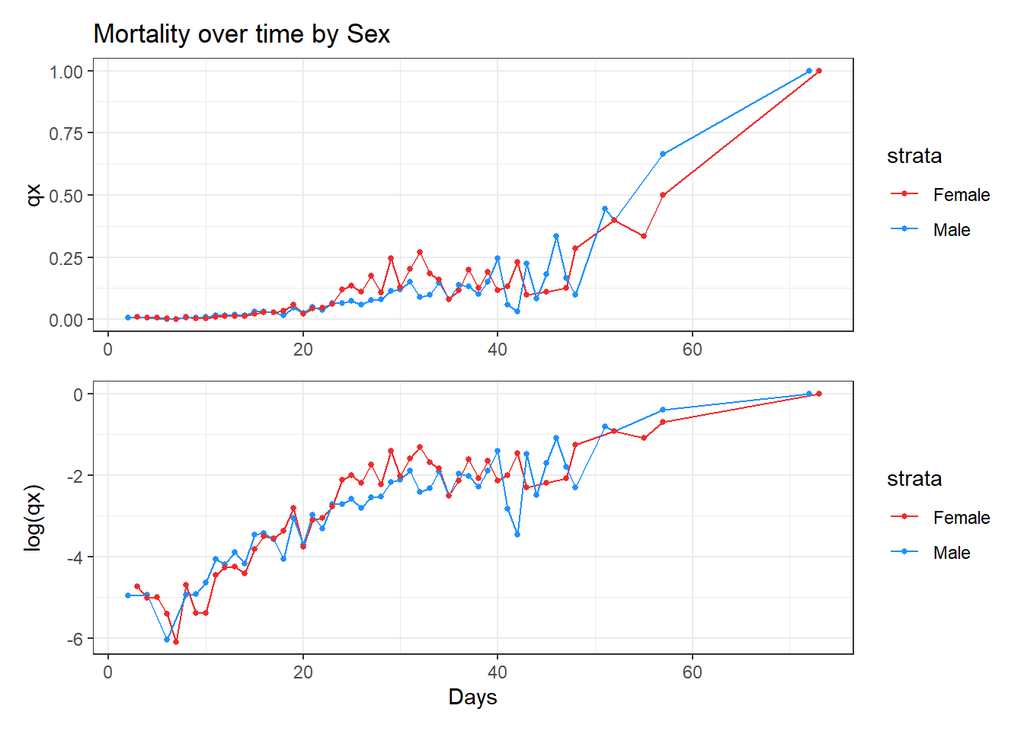

```r
qxplot <- ggplot(mon_sum_DF, aes(x = x, y = qx, color = strata)) +
  geom_line() +
  geom_point(size = 1) +
  scale_color_manual(values = sex_colors) +
  labs(title = "Mortality over time by Sex",
       x = NULL) +
  theme_bw()

qxLogplot <- ggplot(mon_sum_DF, aes(x = x, y = log(qx), color = strata)) +
  geom_line() +
  geom_point(size = 1) +
  scale_color_manual(values = sex_colors) +
  labs(x = "Days") +
  theme_bw()

mortality_plot <- (qxplot / qxLogplot)
mortality_plot
```

### 3.1.4 Save mortality plot

```r
ggsave(
  filename = "../Results/Survival_CoxPH/Figures/Figure_02_mortality_plot.jpg",
  plot = mortality_plot,
  width = 180,
  height = 120,
  units = "mm",
  dpi = 300
)
```

## 3.2 Generate smoothed hazard rates via muhaz by sex

Use the muhaz package to get kernal-density smoothing of hazard rates. We will only estimate hazard rates up to day 45, because otherwise there is not sufficient data (e.g. remaining individuals) to estimate values with acceptable accuracy.

```r
# split by sex
haz_female <- muhaz(
  times = monsurv$Age[monsurv$Sex == "Female"],
  delta = monsurv$event[monsurv$Sex == "Female"],
  max.time = 45
)

haz_male <- muhaz(
  times = monsurv$Age[monsurv$Sex == "Male"],
  delta = monsurv$event[monsurv$Sex == "Male"],
  max.time = 45
)

haz_df <- rbind(
  data.frame(
    age = haz_female$est.grid,
    hazard = haz_female$haz.est,
    loghaz = log(haz_female$haz.est),
    Sex = "Female"
  ),
  data.frame(
    age = haz_male$est.grid,
    hazard = haz_male$haz.est,
    loghaz = log(haz_male$haz.est),
    Sex = "Male"
  )
)
```

### 3.2.1 Visualize muhaz by sex

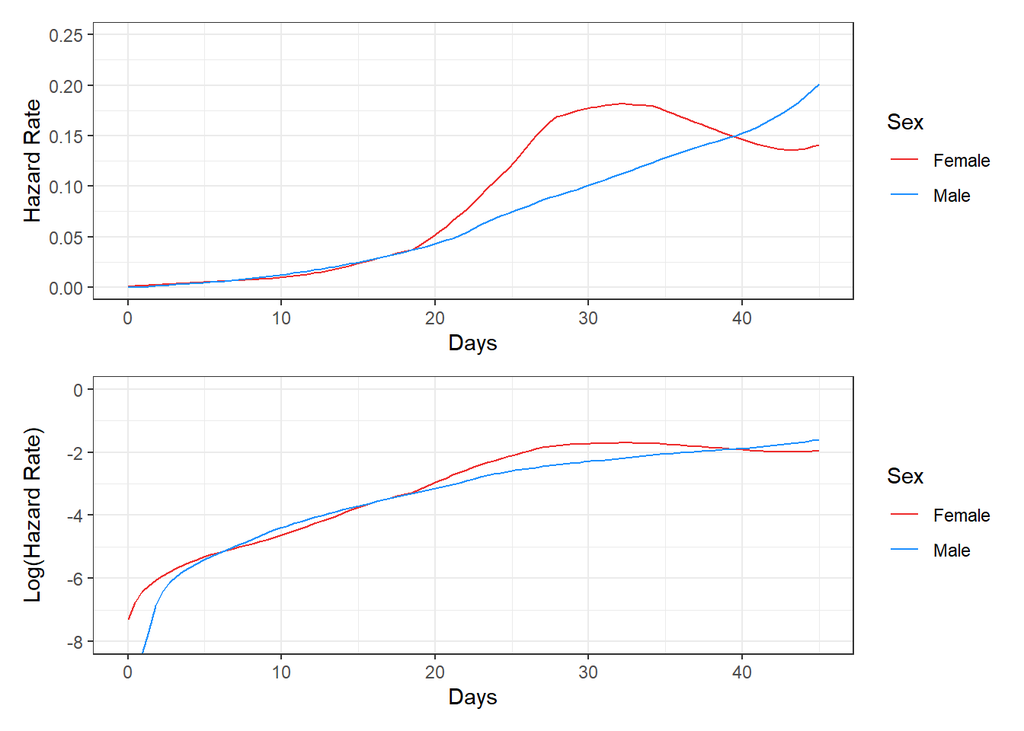

```r
muhaz <- ggplot(haz_df, aes(x = age, y = hazard, color = Sex)) +
  geom_line() +
  scale_color_manual(values = sex_colors) +
  coord_cartesian(ylim = c(0, 0.25)) +
  labs(x = "Days", y = "Hazard Rate") +
  theme_bw()

log_muhaz <- ggplot(haz_df, aes(x = age, y = loghaz, color = Sex)) +
  geom_line() +
  scale_color_manual(values = sex_colors) +
  coord_cartesian(ylim = c(-8, 0)) +
  labs(x = "Days", y = "Log(Hazard Rate)") +
  theme_bw()
full_muhaz <- muhaz / log_muhaz
full_muhaz
```

### 3.2.2 Save smoothed muhaz plot

```r
ggsave(
  "../Results/Survival_CoxPH/Figures/Figure_03_smoothed_muhaz_hazard_plots.jpg",
  plot = full_muhaz,
  width = 180,
  height = 120,
  units = "mm",
  dpi = 300
)
```

### 3.2.3 Plot overlaying manually calculated qx with the smoothed estimates.

```r
liftab.sex <- split(mon_sum_DF, mon_sum_DF$strata)

jpeg("../Results/Survival_CoxPH/Figures/Figure_04_muhaz_overlaid_by_qx.jpg", width = 2400, height = 1200, res = 300)

par(
  mfrow = c(1,2),
  mar = c(4, 4, 2, 1)
)

plot(log(haz_female$haz.est) ~ haz_female$est.grid,
     col = sex_colors["Female"], type = "l", ylim = c(-8,0), xlim = c(0,50),
     ylab = "Log(Hazard Rate)", xlab = "Days", main = "Female")
points(log(liftab.sex$Female$qx) ~ liftab.sex$Female$x,
       col = sex_colors["Female"])

plot(log(haz_male$haz.est) ~ haz_male$est.grid,
     col = sex_colors["Male"], type = "l", ylim = c(-8,0), xlim = c(0,50),
     ylab = "Log(Hazard Rate)", xlab = "Days", main = "Male")
points(log(liftab.sex$Male$qx) ~ liftab.sex$Male$x,
       col = sex_colors["Male"])

dev.off()
```

# 4 CoxPH modeling with wing-length

## 4.1 Modeling using wing-length

```r
m0_nosex <- coxph(Surv(Age, event) ~ WingLength, data = monsurv)
sum_m0_nosex <- summary(m0_nosex)
save_file(sum_m0_nosex,"CoxPH model(WingLength)", coxph_stats)
```

## 4.2 Model with wing-length and sex

```r
m0_sex <- coxph(Surv(Age, event) ~ Sex + WingLength, data = monsurv)
sum_m0_sex <- summary(m0_sex)
save_file(sum_m0_sex,"CoxPH model(WingLength + Sex)", coxph_stats)
```

## 4.3 ANOVA comparison of the two previous models (adding sex does not significantly improve the model)

```r
anova_one <- anova(m0_nosex, m0_sex, test="LRT")
save_file(anova_one,"Anova Comparison CoxPH model(WingLength) vs. CoxPH model(WingLength + Sex)", anova_stats)
```

## 4.4 Contrast survival between males WITH wing-length vs MISSING wing-length, using KM plot

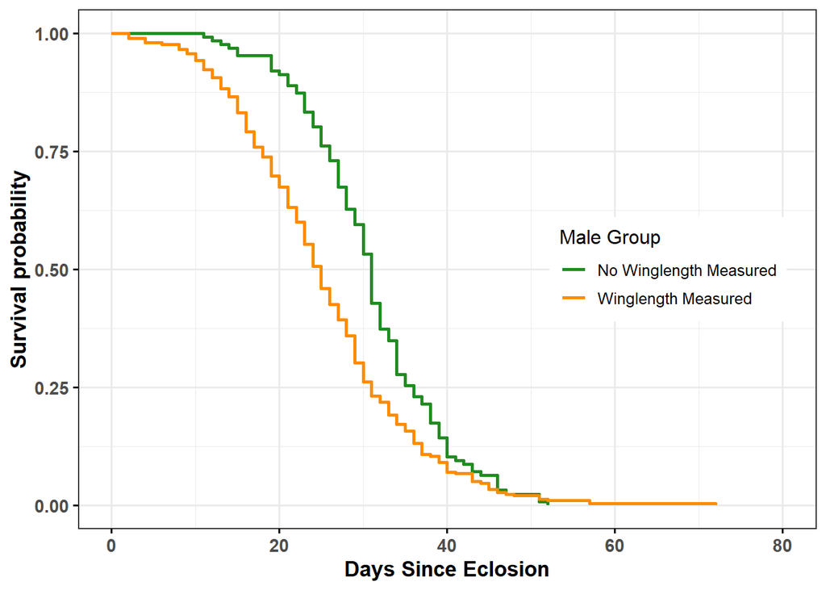

```r
monsurv$male_group <- NA

monsurv$male_group[monsurv$Sex == "Male" & is.na(monsurv$WingLength)] <- "NoWing"
monsurv$male_group[monsurv$Sex == "Male" & !is.na(monsurv$WingLength)] <- "Wing"

male_data <- subset(monsurv, Sex == "Male")

fit <- survfit(Surv(Age, event) ~ male_group, data = male_data)

male_plot <- ggsurvplot(
  fit, data = male_data,
  pval = FALSE,
  risk.table = FALSE,
  legend.title = "Male Group",
  legend.labs = c("No Winglength Measured", "Winglength Measured"),
  legend = c(0.8, 0.5),
  palette = c("forestgreen", "darkorange"),
  ggtheme = theme_monarch,
  xlab = "Days Since Eclosion"
)
print(male_plot)
```

### 4.4.1 Save male_plot

```r
ggsave(
  filename = "../Results/Survival_CoxPH/Figures/Figure_05_male_plot.pdf",
  plot = male_plot$plot,
  width = 180,
  height = 120,
  units = "mm",
  dpi = 300
)
```

### 4.4.2 Do KM test via survdiff for two groups of males (demonstrates that males missing wings are longer lived)

```r
km_test <- survdiff(Surv(Age, event) ~ male_group, data = male_data)
print(km_test)
```

```
Call:
survdiff(formula = Surv(Age, event) ~ male_group, data = male_data)

                    N Observed Expected (O-E)^2/E (O-E)^2/V
male_group=NoWing 126      126      164      8.69      15.7
male_group=Wing   298      298      260      5.47      15.7

 Chisq= 15.7  on 1 degrees of freedom, p= 7e-05
```

```r
save_file(km_test,"Kaplan-Mier statistics for males data", survival_stats)
```

# 5 CoxPH with Forward Discal Cell

## 5.1 Standard fit

Run CoxPH using Sex and normalized size (the z-transformed forward wing discal cell length) as predictors.

## 5.2 Model with only size.

```r
m0_nosex <- coxph(Surv(Age, event) ~ FWdc_z, data = monsurv)
summary(m0_nosex)
```

```
Call:
coxph(formula = Surv(Age, event) ~ FWdc_z, data = monsurv)

  n= 876, number of events= 876

           coef exp(coef) se(coef)      z Pr(>|z|)
FWdc_z -0.26156   0.76985  0.03462 -7.556 4.16e-14 ***
---
Signif. codes:  0 '***' 0.001 '**' 0.01 '*' 0.05 '.' 0.1 ' ' 1

       exp(coef) exp(-coef) lower .95 upper .95
FWdc_z    0.7698      1.299    0.7193    0.8239

Concordance= 0.587  (se = 0.012 )
Likelihood ratio test= 57.65  on 1 df,   p=3e-14
Wald test            = 57.09  on 1 df,   p=4e-14
Score (logrank) test = 56.95  on 1 df,   p=4e-14
```

## 5.3 Model with size + sex.

```r
m0_sex <- coxph(Surv(Age, event) ~ Sex + FWdc_z, data = monsurv)
summary(m0_sex)
```

```
Call:
coxph(formula = Surv(Age, event) ~ Sex + FWdc_z, data = monsurv)

  n= 876, number of events= 876

              coef exp(coef) se(coef)      z Pr(>|z|)
SexFemale  0.12632   1.13465  0.07326  1.724   0.0847 .
FWdc_z    -0.23947   0.78705  0.03694 -6.483 8.99e-11 ***
---
Signif. codes:  0 '***' 0.001 '**' 0.01 '*' 0.05 '.' 0.1 ' ' 1

          exp(coef) exp(-coef) lower .95 upper .95
SexFemale     1.135     0.8813    0.9829    1.3099
FWdc_z        0.787     1.2706    0.7321    0.8461

Concordance= 0.584  (se = 0.011 )
Likelihood ratio test= 60.63  on 2 df,   p=7e-14
Wald test            = 60  on 2 df,   p=9e-14
Score (logrank) test = 60  on 2 df,   p=9e-14
```

## 5.4 Perform LRT via anova to see if there is a significantly better fit with Sex.This is not the case.

```r
anova(m0_nosex, m0_sex, test="LRT")
```

```
Analysis of Deviance Table
 Cox model: response is  Surv(Age, event)
 Model 1: ~ FWdc_z
 Model 2: ~ Sex + FWdc_z
   loglik  Chisq Df Pr(>|Chi|)
1 -5034.7
2 -5033.2 2.9757  1    0.08452 .
---
Signif. codes:  0 '***' 0.001 '**' 0.01 '*' 0.05 '.' 0.1 ' ' 1
```

## 5.5 Diagnostics

Now consider Schoenfeld diagnostics for these predictors. Can check size only, but it is essentially the same with a model with sex included.

```r
czNoSex <- cox.zph(m0_nosex)
print(czNoSex)
```

```
       chisq df      p
FWdc_z     7  1 0.0081
GLOBAL     7  1 0.0081
```

```r
save_file(czNoSex,"Diagnostics of CoxPH model(Forewing discal cell)", diagnostics_stats)
```

### 5.5.1 Plot diagnostics

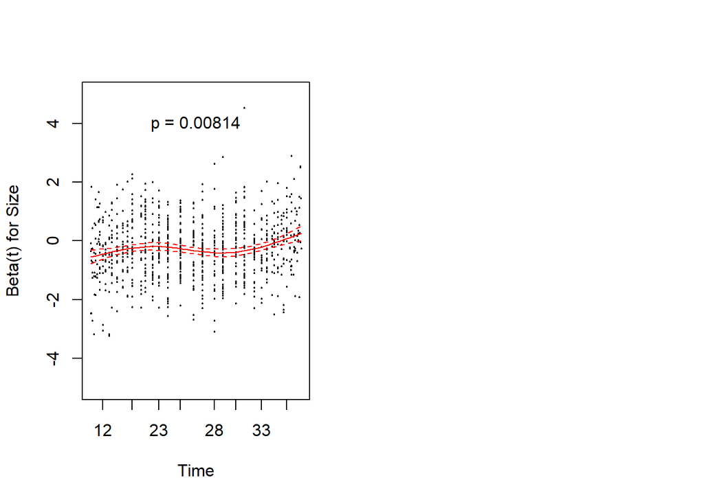

```r
par(mfrow = c(1, 2))

yLim <- c(-5, 5)

plot(
  czNoSex,
  pch = 19,
  cex = 0.2,
  col = "red",
  ylim = yLim,
  ylab = "Beta(t) for Size"
)

pval <- czNoSex$table[1, "p"]

text(
  x = 0.5,
  y = 4,
  labels = paste0("p = ", format.pval(pval, digits = 3))
)
```

### 5.5.2 Save plot

```r
jpeg(
  filename = "../Results/Survival_CoxPH/Figures/Figure_06_size_coxph_diagnostics.jpg",
  width = 180,
  height = 120,
  units = "mm",
  res = 300
)

par(mfrow = c(1, 2))

yLim <- c(-5, 5)

plot(
  czNoSex,
  pch = 19,
  cex = 0.2,
  col = "red",
  ylim = yLim,
  ylab = "Beta(t) for Size"
)

pval <- czNoSex$table[1, "p"]

text(
  x = 0.5,
  y = 4,
  labels = paste0("p = ", format.pval(pval, digits = 3))
)

dev.off()
```

## 5.6 Diagnostics for model with both size and sex.

```r
cz0 <- cox.zph(m0_sex)
print(cz0)
```

```
       chisq df      p
Sex     1.81  1 0.1790
FWdc_z  6.71  1 0.0096
GLOBAL 12.34  2 0.0021
```

```r
save_file(cz0,"Diagnostics of CoxPH model(Forewing discal cell + Size)", diagnostics_stats)
```

### 5.6.1 Plot diagnostics

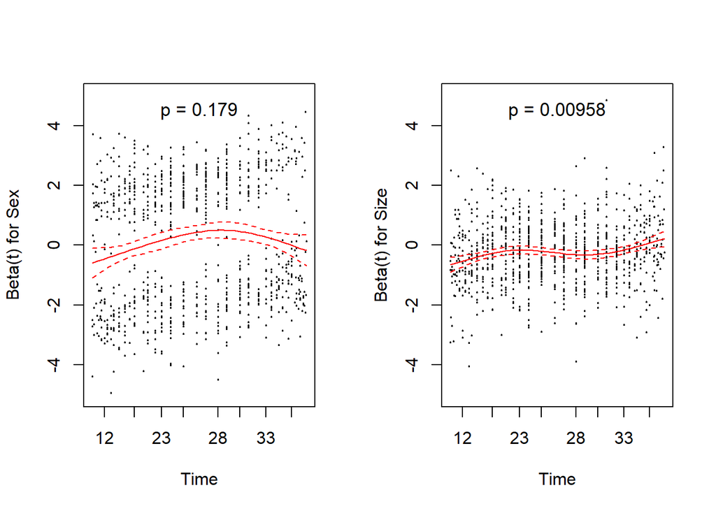

```r
par(mfrow = c(1, 2))

yLim <- c(-5, 5)

# Sex
plot(cz0, var = "Sex",
     pch = 19, cex = 0.2,
     col = "red", ylim = yLim)

p_sex <- cz0$table["Sex", "p"]

text(
  x = 0.5,
  y = 4.5,
  labels = paste0("p = ", format.pval(p_sex, digits = 3)),
  cex = 1.1
)

# FWdc_z
plot(cz0, var = "FWdc_z",
     pch = 19, cex = 0.2,
     col = "red", ylim = yLim, ylab = "")

mtext("Beta(t) for Size", side = 2, line = 2.5)

p_fw <- cz0$table["FWdc_z", "p"]

text(
  x = 0.5,
  y = 4.5,
  labels = paste0("p = ", format.pval(p_fw, digits = 3)),
  cex = 1.1
)
```

### 5.6.2 Save diagnostic plot

```r
jpeg(
  filename = "../Results/Survival_CoxPH/Figures/Figure_07_size_+_sex_coxph_diagnostics.jpg",
  width = 180,
  height = 120,
  units = "mm",
  res = 300
)

par(mfrow = c(1, 2))

yLim <- c(-5, 5)

# Sex
plot(cz0, var = "Sex",
     pch = 19, cex = 0.2,
     col = "red", ylim = yLim)

p_sex <- cz0$table["Sex", "p"]

text(
  x = 0.5,
  y = 4.5,
  labels = paste0("p = ", format.pval(p_sex, digits = 3)),
  cex = 1.1
)

# FWdc_z
plot(cz0, var = "FWdc_z",
     pch = 19, cex = 0.2,
     col = "red", ylim = yLim,
     ylab = "")

mtext("Beta(t) for Size", side = 2, line = 2.5)

p_fw <- cz0$table["FWdc_z", "p"]

text(
  x = 0.5,
  y = 4.5,
  labels = paste0("p = ", format.pval(p_fw, digits = 3)),
  cex = 1.1
)

dev.off()
```

We have a significant violation of CoxPH with time, where larger individuals have (slightly) lower mortality early in life, but seemingly slightly greater late in life. But the relationship isn’t obviously linear, and perhaps even sinusoidal.

So we need to find some way to account for this time-dependency in the model.

## 5.7 Start-Stop Split-Time

The Start-Stop Split-Time approach incorporates time-dependency in the model by appropriately capturing the “risk-set” comparisons through manually splitting the data set into many separate, time-limited, observations of survival. Here we create a new data structure were each row corresponds to a short interval of time.

Doing this should give us the best of both worlds: correct management of “risk-set” comparisons while allowing model-testing and diagnostics. ### Create split

```r
cuts <- seq(0, max(monsurv$Age), by = 1)  # 1-day intervals

ds <- survSplit(
  Surv(Age, event) ~ .,
  data = monsurv,
  cut = cuts[-c(1, length(cuts))],
  start = "tstart",
  end = "tstop",
  event = "event"
)
# define analysis time for the interval (using midpoint)
ds$tmid <- (ds$tstart + ds$tstop) / 2
ds$logtmid <- log(ds$tmid)
```

## 5.8 Fit split models

```r
m_nosex_split <- coxph(Surv(tstart, tstop, event) ~ FWdc_z, data = ds)

m_sex_split <- coxph(Surv(tstart, tstop, event) ~ Sex + FWdc_z, data = ds)

m_nosex_linear_split <-  coxph(Surv(tstart, tstop, event) ~ FWdc_z + FWdc_z:tmid, data = ds)

m_linear_split <-  coxph(Surv(tstart, tstop, event) ~ Sex + FWdc_z + FWdc_z:tmid, data = ds)

m_nosex_log_split <- coxph(Surv(tstart, tstop, event) ~ FWdc_z + FWdc_z:logtmid, data = ds)

m_log_split <- coxph(Surv(tstart, tstop, event) ~ Sex + FWdc_z + FWdc_z:logtmid, data = ds)
```

## 5.9 size model (ST)

```r
m_nosex_split_sum <- summary(m_nosex_split)
print(m_nosex_split_sum)
```

```
Call:
coxph(formula = Surv(tstart, tstop, event) ~ FWdc_z, data = ds)

  n= 22710, number of events= 876

           coef exp(coef) se(coef)      z Pr(>|z|)
FWdc_z -0.26156   0.76985  0.03462 -7.556 4.16e-14 ***
---
Signif. codes:  0 '***' 0.001 '**' 0.01 '*' 0.05 '.' 0.1 ' ' 1

       exp(coef) exp(-coef) lower .95 upper .95
FWdc_z    0.7698      1.299    0.7193    0.8239

Concordance= 0.587  (se = 0.012 )
Likelihood ratio test= 57.65  on 1 df,   p=3e-14
Wald test            = 57.09  on 1 df,   p=4e-14
Score (logrank) test = 56.95  on 1 df,   p=4e-14
```

```r
save_file(m_nosex_split_sum,"CoxPH Model(Forewing discal cell)", coxph_stats)
```

## 5.10 size + sex model(ST)

```r
m_sex_split_sum <- summary(m_sex_split)
print(m_sex_split_sum)
```

```
Call:
coxph(formula = Surv(tstart, tstop, event) ~ Sex + FWdc_z, data = ds)

  n= 22710, number of events= 876

              coef exp(coef) se(coef)      z Pr(>|z|)
SexFemale  0.12632   1.13465  0.07326  1.724   0.0847 .
FWdc_z    -0.23947   0.78705  0.03694 -6.483 8.99e-11 ***
---
Signif. codes:  0 '***' 0.001 '**' 0.01 '*' 0.05 '.' 0.1 ' ' 1

          exp(coef) exp(-coef) lower .95 upper .95
SexFemale     1.135     0.8813    0.9829    1.3099
FWdc_z        0.787     1.2706    0.7321    0.8461

Concordance= 0.584  (se = 0.012 )
Likelihood ratio test= 60.63  on 2 df,   p=7e-14
Wald test            = 60  on 2 df,   p=9e-14
Score (logrank) test = 60  on 2 df,   p=9e-14
```

```r
save_file(m_sex_split_sum,"CoxPH Model(Forewing discal cell + Sex)", coxph_stats)
```

## 5.11 Size + Size:Age model (ST)

```r
m_nosex_linear_split_sum <- summary(m_nosex_linear_split)
save_file(m_nosex_linear_split_sum,"CoxPH Model(Forewing discal cell + Forewing discal cell:Age)", coxph_stats)
```

## 5.12 Sex + Size + Size:Age model (ST)

```r
m_linear_split_sum <- summary(m_linear_split)
save_file(m_linear_split_sum,"CoxPH Model(Forewing discal cell + Sex + Forewing discal cell:Age)", coxph_stats)
```

## 5.13 Size + Size:log(Age) model (ST)

```r
m_nosex_log_split_sum <- summary(m_nosex_log_split)
save_file(m_nosex_log_split_sum,"CoxPH Model(Forewing discal cell + Forewing discal cell:logAge)", coxph_stats)
```

## 5.14 Sex + Size + Size:log(Age) model (ST)

```r
m_log_split_sum <- summary(m_log_split)
save_file(m_log_split_sum,"CoxPH Model(Forewing discal cell + Sex + Forewing discal cell:logAge)", coxph_stats)
```

### 5.14.1 Split model tests

We can compare nested models with LRT, but the linear and log models have the same number of parameters, and are not nested, so these need to be compared via AIC.

First, consider that we have four possible models:

With or without Sex with or without time-variation in size. So we should do model tests that:

Assess size time-variation without Sex This tests wither time-variation “helps” the model fit, ignoring any role of sex. Assess Sex with size time-variation This tests whether including time-variation impacts the significance of sex as a predictor Assess size time-variation with Sex This tests whether the significance of time-variation depends on the inclusion of sex. We can do these three sets of comparisons for the linear and log temporal relationships. But how to decide between linear vs log, since they have the same number of parameters? We will consider both AIC and model diagnostics.

First, we can simply confirm that the split-time models give the same “simple” result that Sex is not significant without considering time-variation in size.

```r
# Confirm absence of "Sex" effect in split-time without time-variation
anova_two <- anova(m_nosex_split, m_sex_split, test = "LRT")
save_file(anova_two,"Anova Comparison CoxPH model(Forewing discal cell) vs. CoxPH model(Forewing discal cell + Sex)", anova_stats)
```

### 5.14.2 Compare linear models

```r
# Test if linear TV in size improves fit, excluding Sex
anova_three <- anova(m_nosex_split, m_nosex_linear_split,  test = "LRT")
save_file(anova_three,"Anova Comparison CoxPH Model(Forewing discal cell) vs. CoxPH Model(Forewing discal cell + Forewing discal cell:Age)", anova_stats)
```

```r
# Compare "Sex" for linear time variation
anova_four <- anova(m_nosex_linear_split, m_linear_split, test = "LRT")
save_file(anova_four,"Anova Comparison CoxPH Model(Forewing discal cell + Forewing discal cell:Age) vs. CoxPH Model(Forewing discal cell + Sex + Forewing discal cell:Age)", anova_stats)
```

```r
# Test if linear TV in size improves fit, including Sex
anova_five <- anova(m_sex_split, m_linear_split, test = "LRT")
save_file(anova_five,"Anova Comparison CoxPH model(Forewing discal cell + Sex) vs. CoxPH model(Forewing discal cell + Sex + Forewing discal cell:Age)", anova_stats)
```

So including linear effects of time-variation on size significantly improves model fit, regardless of including Sex. And Sex remains a non-significant predictor even with including linear time-variation for size.

## 5.15 Compare log models

```r
# Test if log TV in size improves fit, excluding Sex
anova_six <- anova(m_nosex_split, m_nosex_log_split,  test = "LRT")
save_file(anova_six,"Anova Comparison CoxPH model(Forewing discal cell) vs. CoxPH model(Forewing discal cell + Forewing discal cell:logAge)", anova_stats)
```

```r
# Compare "Sex" for log time variation
anova_seven <- anova(m_nosex_log_split, m_log_split, test = "LRT")
save_file(anova_seven,"Anova Comparison CoxPH model(Forewing discal cell + Forewing discal cell:logAge) vs. CoxPH model(Sex + Forewing discal cell + Forewing discal cell:logAge)", anova_stats)
```

```r
# Test if linear TV in size improves fit, including Sex
anova_eight <- anova(m_sex_split, m_log_split, test = "LRT")
save_file(anova_eight,"Anova Comparison CoxPH model(Sex + Forewing discal cell) vs. CoxPH model(Sex + Forewing discal cell + Forewing discal cell:logAge)", anova_stats)
```

Similarly, including log effects of time-variation on size significantly improves model fit, regardless of including Sex. And Sex remains a non-significant predictor even with including log time-variation for size.

## 5.16 Comparison via AIC

Let’s compute AIC on each of these models, even though the only ones we need this for are linear vs log.

```r
aic <- AIC(m_nosex_split, m_sex_split,
          m_nosex_linear_split, m_linear_split,
          m_nosex_log_split, m_log_split)

kbl(aic) %>%  kable_classic("striped") %>%
  scroll_box(width = "60%")
```

|  | df | AIC |
| --- | --- | --- |
| m_nosex_split | 1 | 10071.40 |
| m_sex_split | 2 | 10070.43 |
| m_nosex_linear_split | 2 | 10060.54 |
| m_linear_split | 3 | 10059.95 |
| m_nosex_log_split | 2 | 10061.60 |
| m_log_split | 3 | 10060.83 |

However, we also need to inspect the diagnostics for each of these.

## 5.17 Split diagnostics log-linear

We can examine the diagnostics for these model fits now. What we find in this case is that Sex now violates the diagnostics for both log and linear, seemingly invoking the mid-life shifts we observed in the plots of interval hazard rates.

However, wingsize also significantly violates model assumptions of constant proportional hazards under the linear model. ### Diagnosing the linear model

```r
linsplit.zph <- cox.zph(m_linear_split)
print(linsplit.zph)
```

```
            chisq df     p
Sex          6.43  1 0.011
FWdc_z       5.45  1 0.020
FWdc_z:tmid  0.85  1 0.357
GLOBAL      10.47  3 0.015
```

```r
save_file(linsplit.zph,"Diagnostics of CoxPH model(Forewing discal cell + Sex + Forewing discal cell:Age)", diagnostics_stats)
```

### 5.17.1 View plot in markdown

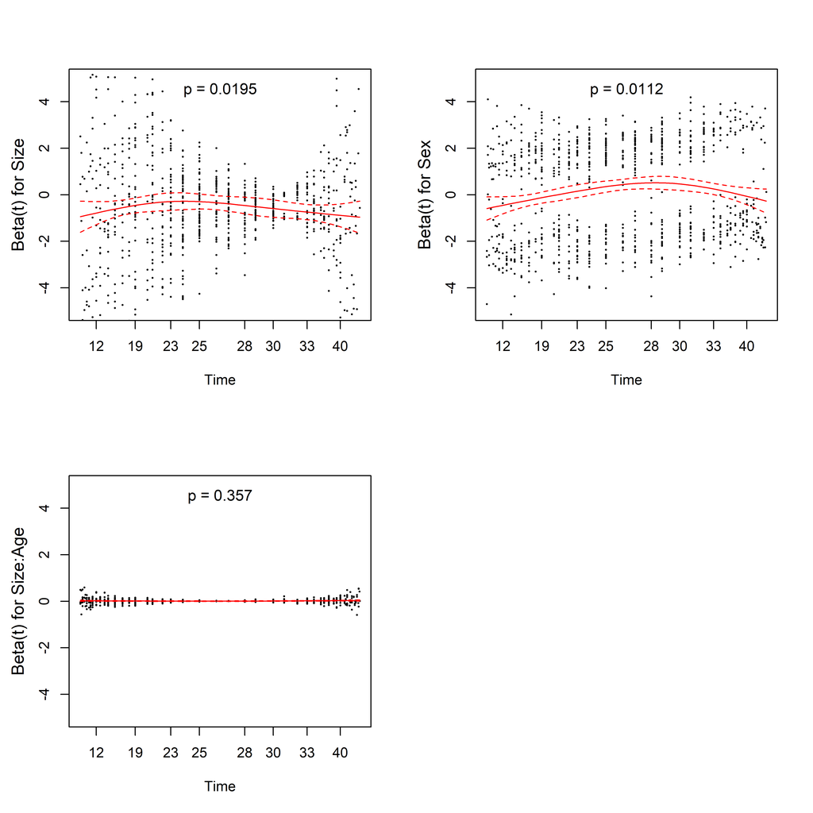

```r
par(mfrow = c(2, 2))

yLim <- c(-5, 5)

# FWdc_z
plot(
  linsplit.zph,
  var = "FWdc_z",
  pch = 19,
  cex = 0.2,
  col = "red",
  ylim = yLim,
  ylab = ""
)

mtext("Beta(t) for Size", side = 2, line = 2.5)

p_fw <- linsplit.zph$table["FWdc_z", "p"]

text(
  x = 0.5,
  y = 4.5,
  labels = paste0("p = ", format.pval(p_fw, digits = 3)),
  cex = 1.1
)

# Sex
plot(
  linsplit.zph,
  var = "Sex",
  pch = 19,
  cex = 0.2,
  col = "red",
  ylim = yLim,
  ylab = ""
)

mtext("Beta(t) for Sex", side = 2, line = 2.5)

p_sex <- linsplit.zph$table["Sex", "p"]

text(
  x = 0.5,
  y = 4.5,
  labels = paste0("p = ", format.pval(p_sex, digits = 3)),
  cex = 1.1
)

# Size:time
plot(
  linsplit.zph,
  var = "FWdc_z:tmid",
  pch = 19,
  cex = 0.2,
  col = "red",
  ylim = yLim,
  ylab = ""
)

mtext("Beta(t) for Size:Age", side = 2, line = 2.5)

p_size_time <- linsplit.zph$table["FWdc_z:tmid", "p"]

text(
  x = 0.5,
  y = 4.5,
  labels = paste0("p = ", format.pval(p_size_time, digits = 3)),
  cex = 1.1
)
```

### 5.17.2 Save plot

```r
jpeg(
  filename = "../Results/Survival_CoxPH/Figures/Figure_08_linear_split_coxph_diagnostics.jpg",
  width = 180,
  height = 160,
  units = "mm",
  res = 300
)

par(mfrow = c(2, 2))

yLim <- c(-5, 5)

# FWdc_z
plot(
  linsplit.zph,
  var = "FWdc_z",
  pch = 19,
  cex = 0.2,
  col = "red",
  ylim = yLim,
  ylab = ""
)

mtext("Beta(t) for Size", side = 2, line = 2.5)

p_fw <- linsplit.zph$table["FWdc_z", "p"]

text(
  x = 0.5,
  y = 4.5,
  labels = paste0("p = ", format.pval(p_fw, digits = 3)),
  cex = 1.1
)

# Sex
plot(
  linsplit.zph,
  var = "Sex",
  pch = 19,
  cex = 0.2,
  col = "red",
  ylim = yLim,
  ylab = ""
)

mtext("Beta(t) for Sex", side = 2, line = 2.5)

p_sex <- linsplit.zph$table["Sex", "p"]

text(
  x = 0.5,
  y = 4.5,
  labels = paste0("p = ", format.pval(p_sex, digits = 3)),
  cex = 1.1
)

# Size:time
plot(
  linsplit.zph,
  var = "FWdc_z:tmid",
  pch = 19,
  cex = 0.2,
  col = "red",
  ylim = yLim,
  ylab = ""
)

mtext("Beta(t) for Size:Age", side = 2, line = 2.5)

p_size_time <- linsplit.zph$table["FWdc_z:tmid", "p"]

text(
  x = 0.5,
  y = 4.5,
  labels = paste0("p = ", format.pval(p_size_time, digits = 3)),
  cex = 1.1
)

dev.off()
```

### 5.17.3 Diagnosing the log model

```r
logsplit.zph <- cox.zph(m_log_split)
print(logsplit.zph)
```

```
                 chisq df      p
Sex             5.8216  1 0.0158
FWdc_z          0.4966  1 0.4810
FWdc_z:logtmid  0.0537  1 0.8168
GLOBAL         12.3709  3 0.0062
```

```r
save_file(logsplit.zph,"Diagnostics of CoxPH model(Forewing discal cell + Sex + Forewing discal cell:logAge)", diagnostics_stats)
```

### 5.17.4 View plot in markdown

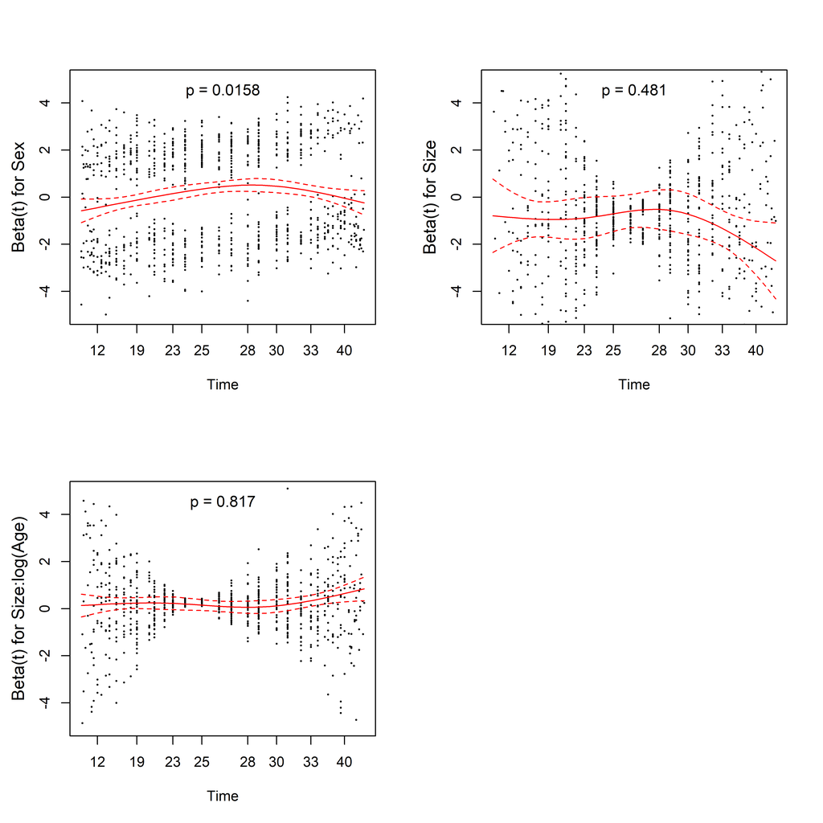

```r
par(mfrow = c(2,2))
yLim <- c(-5, 5)

# Sex
plot(
  logsplit.zph,
  var = "Sex",
  pch = 19,
  cex = 0.2,
  col = "red",
  ylim = yLim,
  ylab = ""
)

mtext("Beta(t) for Sex", side = 2, line = 2.5)

p_sex <- logsplit.zph$table["Sex", "p"]

text(
  x = 0.5,
  y = 4.5,
  labels = paste0("p = ", format.pval(p_sex, digits = 3)),
  cex = 1.1
)


# FWdc_z
plot(
  logsplit.zph,
  var = "FWdc_z",
  pch = 19,
  cex = 0.2,
  col = "red",
  ylim = yLim,
  ylab = ""
)

mtext("Beta(t) for Size", side = 2, line = 2.5)

p_fw <- logsplit.zph$table["FWdc_z", "p"]

text(
  x = 0.5,
  y = 4.5,
  labels = paste0("p = ", format.pval(p_fw, digits = 3)),
  cex = 1.1
)


# FWdc_z:logtmid
plot(
  logsplit.zph,
  var = "FWdc_z:logtmid",
  pch = 19,
  cex = 0.2,
  col = "red",
  ylim = yLim,
  ylab = ""
)

mtext("Beta(t) for Size:log(Age)", side = 2, line = 2.5)

p_log_fw <- logsplit.zph$table["FWdc_z:logtmid", "p"]

text(
  x = 0.5,
  y = 4.5,
  labels = paste0("p = ", format.pval(p_log_fw, digits = 3)),
  cex = 1.1
)
```

### 5.17.5 Save plot

```r
jpeg(
  filename = "../Results/Survival_CoxPH/Figures/Figure_09_log_split_coxph_diagnostics.jpg",
  width = 180,
  height = 160,
  units = "mm",
  res = 300
)

par(mfrow = c(2, 2))
yLim <- c(-5, 5)

# Sex
plot(
  logsplit.zph,
  var = "Sex",
  pch = 19,
  cex = 0.2,
  col = "red",
  ylim = yLim,
  ylab = ""
)

mtext("Beta(t) for Sex", side = 2, line = 2.5)

p_sex <- logsplit.zph$table["Sex", "p"]

text(
  x = 0.5,
  y = 4.5,
  labels = paste0("p = ", format.pval(p_sex, digits = 3)),
  cex = 1.1
)


# FWdc_z
plot(
  logsplit.zph,
  var = "FWdc_z",
  pch = 19,
  cex = 0.2,
  col = "red",
  ylim = yLim,
  ylab = ""
)

mtext("Beta(t) for Size", side = 2, line = 2.5)

p_fw <- logsplit.zph$table["FWdc_z", "p"]

text(
  x = 0.5,
  y = 4.5,
  labels = paste0("p = ", format.pval(p_fw, digits = 3)),
  cex = 1.1
)


# FWdc_z:logtmid
plot(
  logsplit.zph,
  var = "FWdc_z:logtmid",
  pch = 19,
  cex = 0.2,
  col = "red",
  ylim = yLim,
  ylab = ""
)

mtext("Beta(t) for Size:log(Age)", side = 2, line = 2.5)

p_log_fw <- logsplit.zph$table["FWdc_z:logtmid", "p"]

text(
  x = 0.5,
  y = 4.5,
  labels = paste0("p = ", format.pval(p_log_fw, digits = 3)),
  cex = 1.1
)


dev.off()
```

Given that the log model appears to better fit the diagnostics, and that otherwise the models are basically equivalent by AIC, we will proceed with using the log model for wingsize time-dependence. ### Sex-time interaction This diagnostic result points to a time-varying component of Sex, which we can aim to capture with an additional interaction term between Sex and time. We will fit this with log-transformed time as well.

```r
# Log-linear interaction
m_sex_tv_log <- coxph(
  Surv(tstart, tstop, event) ~
    Sex +
    FWdc_z +
    FWdc_z:logtmid +
    Sex:logtmid,
  data = ds
)

summary(m_sex_tv_log)
```

```
Call:
coxph(formula = Surv(tstart, tstop, event) ~ Sex + FWdc_z + FWdc_z:logtmid +
    Sex:logtmid, data = ds)

  n= 22710, number of events= 876

                      coef exp(coef) se(coef)      z Pr(>|z|)
SexFemale         -1.05856   0.34695  0.48244 -2.194   0.0282 *
FWdc_z            -1.18160   0.30679  0.23476 -5.033 4.82e-07 ***
FWdc_z:logtmid     0.29653   1.34519  0.07301  4.062 4.88e-05 ***
SexFemale:logtmid  0.37512   1.45517  0.15163  2.474   0.0134 *
---
Signif. codes:  0 '***' 0.001 '**' 0.01 '*' 0.05 '.' 0.1 ' ' 1

                  exp(coef) exp(-coef) lower .95 upper .95
SexFemale            0.3470     2.8822    0.1348    0.8932
FWdc_z               0.3068     3.2596    0.1936    0.4860
FWdc_z:logtmid       1.3452     0.7434    1.1658    1.5521
SexFemale:logtmid    1.4552     0.6872    1.0811    1.9588

Concordance= 0.595  (se = 0.012 )
Likelihood ratio test= 78.25  on 4 df,   p=4e-16
Wald test            = 78.29  on 4 df,   p=4e-16
Score (logrank) test = 77.58  on 4 df,   p=6e-16
```

We can test the improvement in models via anova().

```r
anova_nine <- anova(m_log_split, m_sex_tv_log, test="LRT")
save_file(anova_nine,"Anova Comparison CoxPH model(Sex + Forewing discal cell + Forewing discal cell:logAge) vs. CoxPH model(Sex + Forewing discal cell + Forewing discal cell:logAge + Sex:logAge)", anova_stats)
```

The model comparison shows the log-time interaction is a significantly better fit. So the Sex:LogTime term significantly improves the model.

## 5.18 Sex-time interactions

```r
sextv.zph <- cox.zph(m_sex_tv_log)
sextv.zph
```

```
                  chisq df       p
Sex            3.68e-01  1 0.54425
FWdc_z         4.54e-01  1 0.50045
FWdc_z:logtmid 4.92e-02  1 0.82449
Sex:logtmid    6.87e-05  1 0.99339
GLOBAL         1.85e+01  4 0.00097
```

```r
save_file(sextv.zph,"Diagnostics of CoxPH model(Forewing discal cell + Sex + Forewing discal cell:logAge + Size:logAge)", diagnostics_stats)
```

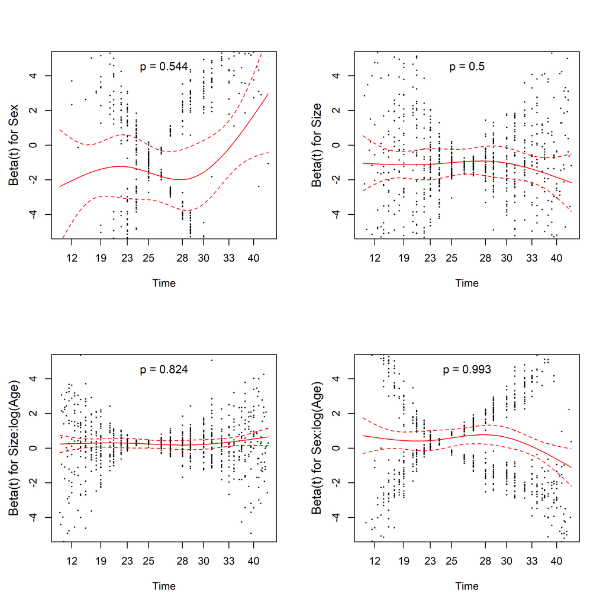

```r
par(mfrow = c(2,2))
yLim <- c(-5, 5)

# Sex
plot(
  sextv.zph,
  var = "Sex",
  pch = 19,
  cex = 0.2,
  col = "red",
  ylim = yLim,
  ylab = ""
)

mtext("Beta(t) for Sex", side = 2, line = 2.5)

p_sex <- sextv.zph$table["Sex", "p"]

text(
  x = 0.5,
  y = 4.5,
  labels = paste0("p = ", format.pval(p_sex, digits = 3)),
  cex = 1.1
)


# FWdc_z
plot(
  sextv.zph,
  var = "FWdc_z",
  pch = 19,
  cex = 0.2,
  col = "red",
  ylim = yLim,
  ylab = ""
)

mtext("Beta(t) for Size", side = 2, line = 2.5)

p_fw <- sextv.zph$table["FWdc_z", "p"]

text(
  x = 0.5,
  y = 4.5,
  labels = paste0("p = ", format.pval(p_fw, digits = 3)),
  cex = 1.1
)


# FWdc_z:logtmid
plot(
  sextv.zph,
  var = "FWdc_z:logtmid",
  pch = 19,
  cex = 0.2,
  col = "red",
  ylim = yLim,
  ylab = ""
)

mtext("Beta(t) for Size:log(Age)", side = 2, line = 2.5)

p_log_fw <- sextv.zph$table["FWdc_z:logtmid", "p"]

text(
  x = 0.5,
  y = 4.5,
  labels = paste0("p = ", format.pval(p_log_fw, digits = 3)),
  cex = 1.1
)

# Sex:logtmid
plot(
  sextv.zph,
  var = "Sex:logtmid",
  pch = 19,
  cex = 0.2,
  col = "red",
  ylim = yLim,
  ylab = ""
)

mtext("Beta(t) for Sex:log(Age)", side = 2, line = 2.5)

p_log_sex <- sextv.zph$table["Sex:logtmid", "p"]

text(
  x = 0.5,
  y = 4.5,
  labels = paste0("p = ", format.pval(p_log_sex, digits = 3)),
  cex = 1.1
)
```

```r
jpeg("../Results/Survival_CoxPH/Figures/Figure_10_log_time_coxph_diagnostics.jpg",
     width = 180, height = 140, units = "mm", res = 300)

par(mfrow = c(2,2))
yLim <- c(-5, 5)

# Sex
plot(
  sextv.zph,
  var = "Sex",
  pch = 19,
  cex = 0.2,
  col = "red",
  ylim = yLim,
  ylab = ""
)

mtext("Beta(t) for Sex", side = 2, line = 2.5)

p_sex <- sextv.zph$table["Sex", "p"]

text(
  x = 0.5,
  y = 4.5,
  labels = paste0("p = ", format.pval(p_sex, digits = 3)),
  cex = 1.1
)


# FWdc_z
plot(
  sextv.zph,
  var = "FWdc_z",
  pch = 19,
  cex = 0.2,
  col = "red",
  ylim = yLim,
  ylab = ""
)

mtext("Beta(t) for Size", side = 2, line = 2.5)

p_fw <- sextv.zph$table["FWdc_z", "p"]

text(
  x = 0.5,
  y = 4.5,
  labels = paste0("p = ", format.pval(p_fw, digits = 3)),
  cex = 1.1
)


# FWdc_z:logtmid
plot(
  sextv.zph,
  var = "FWdc_z:logtmid",
  pch = 19,
  cex = 0.2,
  col = "red",
  ylim = yLim,
  ylab = ""
)

mtext("Beta(t) for Size:log(Age)", side = 2, line = 2.5)

p_log_fw <- sextv.zph$table["FWdc_z:logtmid", "p"]

text(
  x = 0.5,
  y = 4.5,
  labels = paste0("p = ", format.pval(p_log_fw, digits = 3)),
  cex = 1.1
)

# Sex:logtmid
plot(
  sextv.zph,
  var = "Sex:logtmid",
  pch = 19,
  cex = 0.2,
  col = "red",
  ylim = yLim,
  ylab = ""
)

mtext("Beta(t) for Sex:log(Age)", side = 2, line = 2.5)

p_log_sex <- sextv.zph$table["Sex:logtmid", "p"]

text(
  x = 0.5,
  y = 4.5,
  labels = paste0("p = ", format.pval(p_log_sex, digits = 3)),
  cex = 1.1
)

dev.off()
```

### 5.18.1 Sex-time AIC

Let’s compute AIC on each of these models, even though the only ones we need this for are linear vs log.

```r
aic <- AIC(m_nosex_split, m_sex_split,
          m_nosex_linear_split, m_linear_split,
          m_nosex_log_split, m_log_split,
          m_sex_tv_log)

kbl(aic) %>%  kable_classic("striped") %>%
  scroll_box(width = "60%")
```

|  | df | AIC |
| --- | --- | --- |
| m_nosex_split | 1 | 10071.40 |
| m_sex_split | 2 | 10070.43 |
| m_nosex_linear_split | 2 | 10060.54 |
| m_linear_split | 3 | 10059.95 |
| m_nosex_log_split | 2 | 10061.60 |
| m_log_split | 3 | 10060.83 |
| m_sex_tv_log | 4 | 10056.80 |

### 5.18.2 Interpretations

We will interpret the coefficients of our best model (log-time interaction). These are in “log hazard” scale: negative numbers mean a reduced hazard rate relative to the reference.

```r
coef(m_sex_tv_log)
```

```
        SexFemale            FWdc_z    FWdc_z:logtmid SexFemale:logtmid
       -1.0585639        -1.1816006         0.2965349         0.3751245
```

Accordingly, for sex:

At early times, female hazard is lower than males; females are less likely to die. As time advances the HR approaches and then passes 1, and later in life, females hazard exceeds males. Here is a function, based on the model coefficients, to calculate the hazard ratio of females relative to males at any given time. Then we can calculate the M:F hazard ratio at a couple of time points.

```r
femHR <- function(timepoint) {
  coefs <- coef(m_sex_tv_log)
  beta_t <- coefs["SexFemale"] + coefs["SexFemale:logtmid"]*log(timepoint)
  hr_t <- exp(beta_t)
  return(hr_t)
}

times <- seq(5, 25, 5)
round(femHR(times), digits =  2)
```

```
[1] 0.63 0.82 0.96 1.07 1.16
```

Assuming an ‘average-sized’ butterfly, the hazard ratio bypasses 1 (meaning the relative impact of sex flips) at day 17.

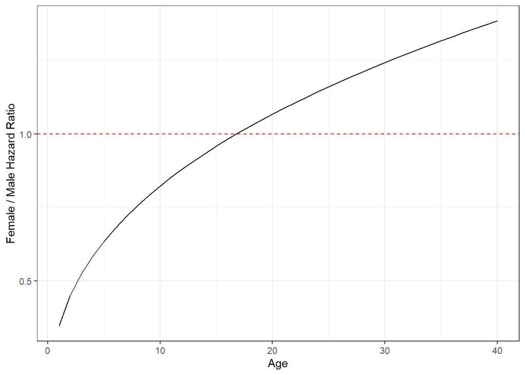

```r
times <- c(1:40)
df <- data.frame(
  age = times,
  hazard_ratio = femHR(times)
)

hazard_ratio_plot <- ggplot(df, aes(age, hazard_ratio)) +
  geom_line() +
  geom_hline(yintercept = 1, linetype = 2, color = "red") +
  labs(
    x = "Age",
    y = "Female / Male Hazard Ratio"
  ) +
  scale_y_continuous(breaks = seq(0, 1.5, by = 0.5)) +
  theme_bw()
print(hazard_ratio_plot)
```

#### 5.18.2.1 Save ‘hazard ratio’ plot

```r
ggsave(
  filename = "../Results/Survival_CoxPH/Figures/Figure_11_hazard_ratio.jpg",
  plot = hazard_ratio_plot,
  width = 180,
  height = 120,
  units = "mm",
  dpi = 300
)
```

Size follows a similar pattern, but since it is a continuous variable it is slightly different to think about. In this case, since we normalized to Z-scale, our unit is standard deviation.

Accordingly, a larger size will have reduced hazard, at least early in life. However, that effect reduces as time increases. So later in life, size offers relatively little protection, and possibly hurts.

## 5.19 Time transformation

With a continuous predictor like size, the survival package recommends using a “time transformation” (tt) function, which will appropriately capture the time-variation of such predictors via a mathematical function. This handles the “risk-set” issue in a dynamic way, and avoids the “borrowing information from the future” problem of fitting models with fixed-ages as predictors.

This is addressed in further detail in section 4.2 of the Time dependent analysis vignette from the survival package.

We can again fit all three versions of interactions between size and time. The problem here, as will see, is that this doesn’t allows us to examine the diagnostics with cox.zph(). Apparently, this diagnostic functiondoesn’t support models fit using tt().

Nonetheless, we’ll do this:

### 5.19.1 tt() model with Size + Size:age

```r
m_nosex_tt_lin <- coxph(
  Surv(Age, event) ~ FWdc_z + tt(FWdc_z),
  data = monsurv,
  tt = function(x, t, ...) x * t
)
m_nosex_tt_lin_sum <- summary(m_nosex_tt_lin)
save_file(m_nosex_tt_lin_sum,"CoxPH Model(Forewing discal cell + Forewing discal cell:tt(Age))", coxph_stats)
print(m_nosex_tt_lin_sum)
```

```
Call:
coxph(formula = Surv(Age, event) ~ FWdc_z + tt(FWdc_z), data = monsurv,
    tt = function(x, t, ...) x * t)

  n= 876, number of events= 876

                coef exp(coef)  se(coef)      z Pr(>|z|)
FWdc_z     -0.591044  0.553749  0.098970 -5.972 2.34e-09 ***
tt(FWdc_z)  0.012336  1.012413  0.003479  3.546 0.000391 ***
---
Signif. codes:  0 '***' 0.001 '**' 0.01 '*' 0.05 '.' 0.1 ' ' 1

           exp(coef) exp(-coef) lower .95 upper .95
FWdc_z        0.5537     1.8059    0.4561    0.6723
tt(FWdc_z)    1.0124     0.9877    1.0055    1.0193

Concordance= 0.587  (se = 0.012 )
Likelihood ratio test= 70.51  on 2 df,   p=5e-16
Wald test            = 69.29  on 2 df,   p=9e-16
Score (logrank) test = 68.95  on 2 df,   p=1e-15
```

### 5.19.2 tt() model with Size + Size:age + Sex

```r
m_tt_lin <- coxph(
  Surv(Age, event) ~ Sex + FWdc_z + tt(FWdc_z),
  data = monsurv,
  tt = function(x, t, ...) x * t
)
m_tt_lin_sum <- summary(m_tt_lin)
save_file(m_tt_lin_sum,"CoxPH Model(Sex + Forewing discal cell + Forewing discal cell:tt(Age))", coxph_stats)
print(m_tt_lin_sum)
```

```
Call:
coxph(formula = Surv(Age, event) ~ Sex + FWdc_z + tt(FWdc_z),
    data = monsurv, tt = function(x, t, ...) x * t)

  n= 876, number of events= 876

                coef exp(coef)  se(coef)      z Pr(>|z|)
SexFemale   0.117959  1.125198  0.073268  1.610 0.107408
FWdc_z     -0.565423  0.568120  0.100197 -5.643 1.67e-08 ***
tt(FWdc_z)  0.012115  1.012189  0.003469  3.492 0.000479 ***
---
Signif. codes:  0 '***' 0.001 '**' 0.01 '*' 0.05 '.' 0.1 ' ' 1

           exp(coef) exp(-coef) lower .95 upper .95
SexFemale     1.1252     0.8887    0.9747    1.2990
FWdc_z        0.5681     1.7602    0.4668    0.6914
tt(FWdc_z)    1.0122     0.9880    1.0053    1.0191

Concordance= 0.587  (se = 0.012 )
Likelihood ratio test= 73.11  on 3 df,   p=9e-16
Wald test            = 71.47  on 3 df,   p=2e-15
Score (logrank) test = 71.39  on 3 df,   p=2e-15
```

## 5.20 tt() Logarithmic fit

### 5.20.1 tt() model with Size + Size:log(age)

```r
m_nosex_tt_log <- coxph(
  Surv(Age, event) ~ FWdc_z + tt(FWdc_z),
  data = monsurv,
  tt = function(x, t, ...) x * log(t)
)
m_nosex_tt_log_sum <- summary(m_nosex_tt_log)
save_file(m_nosex_tt_log_sum,"CoxPH Model(Forewing discal cell + Forewing discal cell:log(tt(Age)))", coxph_stats)
print(m_nosex_tt_log_sum)
```

```
Call:
coxph(formula = Surv(Age, event) ~ FWdc_z + tt(FWdc_z), data = monsurv,
    tt = function(x, t, ...) x * log(t))

  n= 876, number of events= 876

               coef exp(coef) se(coef)      z Pr(>|z|)
FWdc_z     -1.07782   0.34034  0.24015 -4.488 7.18e-06 ***
tt(FWdc_z)  0.25532   1.29087  0.07434  3.434 0.000594 ***
---
Signif. codes:  0 '***' 0.001 '**' 0.01 '*' 0.05 '.' 0.1 ' ' 1

           exp(coef) exp(-coef) lower .95 upper .95
FWdc_z        0.3403     2.9383    0.2126    0.5449
tt(FWdc_z)    1.2909     0.7747    1.1158    1.4934

Concordance= 0.587  (se = 0.012 )
Likelihood ratio test= 69.49  on 2 df,   p=8e-16
Wald test            = 68.53  on 2 df,   p=1e-15
Score (logrank) test = 68.08  on 2 df,   p=2e-15
```

### 5.20.2 tt() model with Size + Size:log(age) + Sex

```r
m_tt_log <- coxph(
  Surv(Age, event) ~ Sex + FWdc_z + tt(FWdc_z),
  data = monsurv,
  tt = function(x, t, ...) x * log(t)
)
m_tt_log_sum <- summary(m_tt_log)
save_file(m_tt_log_sum,"CoxPH Model(Sex + Forewing discal cell + Forewing discal cell:log(tt(Age)))", coxph_stats)
print(m_tt_log_sum)
```

```
Call:
coxph(formula = Surv(Age, event) ~ Sex + FWdc_z + tt(FWdc_z),
    data = monsurv, tt = function(x, t, ...) x * log(t))

  n= 876, number of events= 876

               coef exp(coef) se(coef)      z Pr(>|z|)
SexFemale   0.12176   1.12948  0.07330  1.661 0.096677 .
FWdc_z     -1.05050   0.34976  0.24118 -4.356 1.33e-05 ***
tt(FWdc_z)  0.25321   1.28816  0.07443  3.402 0.000669 ***
---
Signif. codes:  0 '***' 0.001 '**' 0.01 '*' 0.05 '.' 0.1 ' ' 1

           exp(coef) exp(-coef) lower .95 upper .95
SexFemale     1.1295     0.8854    0.9783    1.3040
FWdc_z        0.3498     2.8591    0.2180    0.5611
tt(FWdc_z)    1.2882     0.7763    1.1133    1.4905

Concordance= 0.587  (se = 0.012 )
Likelihood ratio test= 72.25  on 3 df,   p=1e-15
Wald test            = 70.86  on 3 df,   p=3e-15
Score (logrank) test = 70.68  on 3 df,   p=3e-15
```

### 5.20.3 tt() model with Size + Size:log(age) + Sex + Sex:log(age)

```r
monsurv$Male <- as.numeric(monsurv$Sex == "Male")
m_tt_sex_log <- coxph(
  Surv(Age, event) ~ Sex + FWdc_z + tt(FWdc_z) + tt(Male),
  data = monsurv,
  tt = function(x, t, ...) x * log(t)
)
m_tt_sex_log_sum <- summary(m_tt_sex_log)
save_file(m_tt_log_sum,"CoxPH Model(Sex + Forewing discal cell + Forewing discal cell:log(tt(Age)) + Sex:log(tt(Age)))", coxph_stats)
print(m_tt_sex_log_sum)
```

```
Call:
coxph(formula = Surv(Age, event) ~ Sex + FWdc_z + tt(FWdc_z) +
    tt(Male), data = monsurv, tt = function(x, t, ...) x * log(t))

  n= 876, number of events= 876

               coef exp(coef) se(coef)      z Pr(>|z|)
SexFemale  -1.11886   0.32665  0.50784 -2.203   0.0276 *
FWdc_z     -1.23174   0.29178  0.24702 -4.986 6.15e-07 ***
tt(FWdc_z)  0.30992   1.36332  0.07632  4.061 4.89e-05 ***
tt(Male)   -0.39112   0.67630  0.15853 -2.467   0.0136 *
---
Signif. codes:  0 '***' 0.001 '**' 0.01 '*' 0.05 '.' 0.1 ' ' 1

           exp(coef) exp(-coef) lower .95 upper .95
SexFemale     0.3267     3.0614    0.1207    0.8838
FWdc_z        0.2918     3.4272    0.1798    0.4735
tt(FWdc_z)    1.3633     0.7335    1.1739    1.5833
tt(Male)      0.6763     1.4786    0.4957    0.9227

Concordance= 0.595  (se = 0.012 )
Likelihood ratio test= 78.25  on 4 df,   p=4e-16
Wald test            = 78.21  on 4 df,   p=4e-16
Score (logrank) test = 77.53  on 4 df,   p=6e-16
```

## 5.21 tt() model comparisons

Adding sex to a model with size and size:age does not significantly improve the model.

```r
anova_ten <- anova(m_nosex_tt_lin, m_tt_lin, test="LRT")
save_file(anova_ten,"Anova Comparison CoxPH Model(Forewing discal cell + Forewing discal cell:tt(Age)) vs. CoxPH Model(Sex + Forewing discal cell + Forewing discal cell:tt(Age))", anova_stats)
print(anova_ten)
```

```
Analysis of Deviance Table
 Cox model: response is  Surv(Age, event)
 Model 1: ~ FWdc_z + tt(FWdc_z)
 Model 2: ~ Sex + FWdc_z + tt(FWdc_z)
   loglik  Chisq Df Pr(>|Chi|)
1 -5028.3
2 -5027.0 2.5944  1     0.1072
```

Adding sex to a model with size + size:log(age) does not significantly improve the model.

```r
anova_eleven <- anova(m_nosex_tt_log, m_tt_log, test="LRT")
save_file(anova_eleven,"Anova Comparison CoxPH Model(Forewing discal cell + Forewing discal cell:log(tt(Age))) vs. CoxPH Model(Sex + Forewing discal cell + Forewing discal cell:log(tt(Age)))", anova_stats)
print(anova_eleven)
```

```
Analysis of Deviance Table
 Cox model: response is  Surv(Age, event)
 Model 1: ~ FWdc_z + tt(FWdc_z)
 Model 2: ~ Sex + FWdc_z + tt(FWdc_z)
   loglik  Chisq Df Pr(>|Chi|)
1 -5028.8
2 -5027.4 2.7621  1    0.09652 .
---
Signif. codes:  0 '***' 0.001 '**' 0.01 '*' 0.05 '.' 0.1 ' ' 1
```

Adding sex:log(age) to a model with sex + size + size:log(age) significantly improves the model.

```r
anova_twelve <- anova(m_tt_log, m_tt_sex_log, test="LRT")
save_file(anova_twelve,"Anova Comparison CoxPH Model(Sex + Forewing discal cell + Forewing discal cell:log(tt(Age))) vs. CoxPH Model(Sex + Forewing discal cell + Forewing discal cell:log(tt(Age)) + Sex:log(tt(Age)))", anova_stats)
print(anova_twelve)
```

```
Analysis of Deviance Table
 Cox model: response is  Surv(Age, event)
 Model 1: ~ Sex + FWdc_z + tt(FWdc_z)
 Model 2: ~ Sex + FWdc_z + tt(FWdc_z) + tt(Male)
   loglik  Chisq Df Pr(>|Chi|)
1 -5027.4
2 -5024.4 5.9943  1    0.01435 *
---
Signif. codes:  0 '***' 0.001 '**' 0.01 '*' 0.05 '.' 0.1 ' ' 1
```

## 5.22 Compare models via AIC

We can’t compare between linear versus log with LRT because they have the same number of parameters are are not nested. Though we can examine AIC.

```r
aic <- AIC(m0_nosex, m0_sex,
           m_nosex_tt_lin, m_tt_lin,
           m_nosex_tt_log, m_tt_log, m_tt_sex_log)

kbl(aic) %>%  kable_classic("striped") %>%
  scroll_box(width = "60%")
```

|  | df | AIC |
| --- | --- | --- |
| m0_nosex | 1 | 10071.40 |
| m0_sex | 2 | 10070.43 |
| m_nosex_tt_lin | 2 | 10060.54 |
| m_tt_lin | 3 | 10059.95 |
| m_nosex_tt_log | 2 | 10061.56 |
| m_tt_log | 3 | 10060.80 |
| m_tt_sex_log | 4 | 10056.81 |

First, AIC clearly shows the tt() models with the effect of size time-varying are far better models. So even without the LRT comparison, this is strong support for including time-variation or size in the model.

As for linear vs log, parsimony, and the slightly better AIC, would argue for linear. But ultimately, it doesn’t really seem to matter, because it doesn’t substantively change the results of parameter estimates or significance. These models are arguably equivalent.

### 5.22.1 Can’t diagnose tt()

Unfortunately, as mentioned above, Schoenfeld diagnostics does not function for time-transformation models.So we don’t really know how well the models are doing relative to assumptions ### Model comparisons Here we are generating a table of results that report relevant models, comparisons via LRT, and the deltaAIC relative to the lowest model.

```r
# --------------------------------------------------
# Model comparison table for split-time CoxPH models
# --------------------------------------------------

model_fits <- list(
  M1 = m_nosex_split,
  M2 = m_sex_split,
  M3 = m_nosex_linear_split,
  M4 = m_linear_split,
  M5 = m_nosex_log_split,
  M6 = m_log_split,
  M7 = m_sex_tv_log
)

predictor_labels <- tibble(
  Model = names(model_fits),
  Predictors = c(
    "Size",
    "Size + Sex",
    "Size + Size × Time",
    "Size + Size × Time + Sex",
    "Size + Size × log(Time)",
    "Size + Size × log(Time) + Sex",
    "Size + Size × log(Time) + Sex + Sex × log(Time)"
  )
)

aic_tbl <- AIC(
  m_nosex_split,
  m_sex_split,
  m_nosex_linear_split,
  m_linear_split,
  m_nosex_log_split,
  m_log_split,
  m_sex_tv_log
) %>%
  as.data.frame() %>%
  rownames_to_column("fit_name") %>%
  mutate(
    Model = names(model_fits),
    delta_AIC = AIC - min(AIC)
  ) %>%
  select(Model, df, AIC, delta_AIC)

get_lrt <- function(fit_less, fit_more) {
  out <- anova(fit_less, fit_more, test = "LRT")

  tibble(
    LRT = out$Chisq[2],
    LRT_df = out$Df[2],
    p_value = out$`Pr(>|Chi|)`[2]
  )
}

lrt_tbl <- bind_rows(
  tibble(Model = "M1", Comparison = NA_character_, LRT = NA_real_, LRT_df = NA_real_, p_value = NA_real_),
  get_lrt(m_nosex_split, m_sex_split) %>% mutate(Model = "M2", Comparison = "M1 vs M2: + Sex"),
  get_lrt(m_nosex_split, m_nosex_linear_split) %>% mutate(Model = "M3", Comparison = "M1 vs M3: + Size × Time"),
  get_lrt(m_nosex_linear_split, m_linear_split) %>% mutate(Model = "M4", Comparison = "M3 vs M4: + Sex"),
  get_lrt(m_nosex_split, m_nosex_log_split) %>% mutate(Model = "M5", Comparison = "M1 vs M5: + Size × log(Time)"),
  get_lrt(m_nosex_log_split, m_log_split) %>% mutate(Model = "M6", Comparison = "M5 vs M6: + Sex"),
  get_lrt(m_log_split, m_sex_tv_log) %>% mutate(Model = "M7", Comparison = "M6 vs M7: + Sex × log(Time)")
) %>%
  select(Model, Comparison, LRT, LRT_df, p_value)

model_test_tbl <- predictor_labels %>%
  left_join(aic_tbl, by = "Model") %>%
  left_join(lrt_tbl, by = "Model") %>%
  mutate(
    across(c(AIC, delta_AIC, LRT, p_value), ~ round(.x, 4))
  )


write_csv(model_test_tbl, "../Results/Survival_CoxPH/Statistics/cox_split_time_model_comparison.csv")


kbl(model_test_tbl) %>%  kable_classic("striped") %>%
  scroll_box(width = "100%")
```

| Model | Predictors | df | AIC | delta_AIC | Comparison | LRT | LRT_df | p_value |
| --- | --- | --- | --- | --- | --- | --- | --- | --- |
| M1 | Size | 1 | 10071.40 | 14.6009 | NA | NA | NA | NA |
| M2 | Size + Sex | 2 | 10070.43 | 13.6252 | M1 vs M2: + Sex | 2.9757 | 1 | 0.0845 |
| M3 | Size + Size × Time | 2 | 10060.54 | 3.7428 | M1 vs M3: + Size × Time | 12.8581 | 1 | 0.0003 |
| M4 | Size + Size × Time + Sex | 3 | 10059.95 | 3.1484 | M3 vs M4: + Sex | 2.5944 | 1 | 0.1072 |
| M5 | Size + Size × log(Time) | 2 | 10061.60 | 4.7993 | M1 vs M5: + Size × log(Time) | 11.8016 | 1 | 0.0006 |
| M6 | Size + Size × log(Time) + Sex | 3 | 10060.83 | 4.0282 | M5 vs M6: + Sex | 2.7711 | 1 | 0.0960 |
| M7 | Size + Size × log(Time) + Sex + Sex × log(Time) | 4 | 10056.80 | 0.0000 | M6 vs M7: + Sex × log(Time) | 6.0282 | 1 | 0.0141 |

## 5.23 Create 3-panel figure

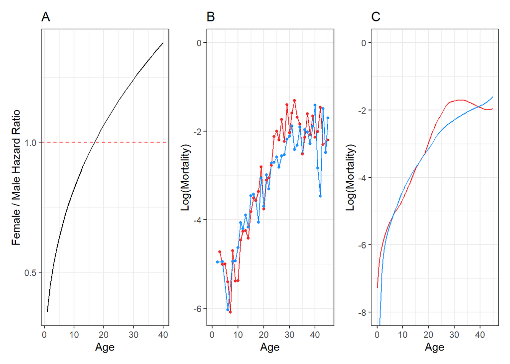

```r
## Panel A: Female/Male hazard ratio
hazard_ratio_plot <- ggplot(df, aes(age, hazard_ratio)) +
  geom_line() +
  geom_hline(yintercept = 1, linetype = 2, color = "red") +
  labs(
    x = "Age",
    y = "Female / Male Hazard Ratio"
  ) +
  scale_y_continuous(breaks = seq(0, 1.5, by = 0.5)) +
  theme_bw() + ggtitle('A')
## Panel B: qx
qxLogplot <- ggplot(mon_sum_DF, aes(x = x, y = log(qx), color = strata)) +
  geom_line() +
  geom_point(size = 1) +
  scale_color_manual(values = sex_colors) +
  labs(x = "Age",
       y = "Log(Mortality)") +
  xlim(0, 45) +
  theme_bw() +
  theme(legend.position = "none") + ggtitle('B')

## Panel C: Smoothed log hazard
haz_df <- rbind(
  data.frame(
    age = haz_female$est.grid,
    loghaz = log(haz_female$haz.est),
    Sex = "Female"
  ),
  data.frame(
    age = haz_male$est.grid,
    loghaz = log(haz_male$haz.est),
    Sex = "Male"
  )
)

log_muhaz <- ggplot(haz_df, aes(x = age, y = loghaz, color = Sex)) +
  geom_line() +
  scale_color_manual(values = sex_colors) +
  labs(
    x = "Age",
    y = "Log(Mortality)"
  ) +
  coord_cartesian(ylim = c(-8, 0)) +
  theme_bw() +
  theme(legend.position = "none") + ggtitle('C')


final_fig <-
  hazard_ratio_plot | qxLogplot | log_muhaz +
  plot_annotation(tag_levels = "A")

final_fig
```

### 5.23.1 Save plot

```r
ggsave(
  filename = "../Results/Survival_CoxPH/Figures/Figure_12_Figure3Panels.pdf",
  plot = final_fig,
  width = 280,
  height = 120,
  units = "mm",
  dpi = 300
)
```